# Chapter_1_Master

Cindy Fajardo

2025-12-08

#Welcome This Rmarkdown file will be used for the first chapter of my Master’s thesis. You will find data manipulation, visualizations, and statistical analysis of data that I collected on the owl limpet population found at Cabrillo National Monument Zone 3 from September 2023- June 2024. The following ecological/biological concepts that are covered are

- Seasonal Growth Rates
- Seasonal Changes in Population Distribution
- Seasonal Changes in Population Density
- Seasonal changes in local community composition in presence/absence of central owl limpet

Below you will find the data frames that I used. Enjoy!

#Libraries But first, lets load the libraries I used/have stored here for easy convenience

```r
library("rerddap")
library(tidyverse)
library("tidync")
library("doParallel")
library(lubridate)
library(patchwork)
library(viridis)
library(here)
library(kableExtra)
library(hrbrthemes)
library(emmeans)
library(agricolae)
library(vegan)
library(performance)
library(broom)
library(car)
library(lme4)
library(lmerTest)
library(pscl)
library(ggridges)
library(devtools)
#library(pairwiseAdonis)
library(FSA)
library(see)
library(RColorBrewer)
```

# Read in CSV

In this chunk, I am reading in the csv’s that are relevant to growth and community survey data ONLY

```r
master_sl <- read_csv(here("Data","Master_CNM_OL_SL_Data.csv")) %>%
  filter(!Plot_Name %in% c("CNM_7", "CNM_8" )) %>% #filtered out transects not found in all seasons, do %in% to other lines
mutate(sex=ifelse(SL_mm>= 50, "female", "male"))

sess_percentcover <- read_csv(here("Data", "Master_CNM_Sessile_Percent_Data.csv")) %>%
  filter(!Transect%in% c("CNM_7", "CNM_8")) #filtered out transects not found in all seasons

mobiles_master <- read.csv(here("Data", "Master_CNM_Mobile_Data.csv")) %>%
  filter(!Transect %in% c("CNM_7", "CNM_8")) #filtered out transects not found in all seasons

mobiles_matrix_master <- read.csv(here("Data", "Master_CNM_Mobile_Matrix.csv")) %>%
  filter(!Transect %in% c("CNM_7", "CNM_8")) #filtered out transects not found in all seasons

sessile_matrix_master <- read.csv(here("Data", "Master_CNM_Sessile_Matrix.csv")) %>%
  filter(!Transect %in% c("CNM_7", "CNM_8")) #filtered out transects not found in all seasons

cabrillo_yearly_lim_size <- read_csv(here("Data", "yearly_lim_size.csv"))

master_temperature_data <- read.csv(here("Data", "Logger_CNM_2_2023_10_01__2024_06_10.csv"))
```

# Complete Growth Data

I’m leaving this chunk in for reference to code with geom_smooth

```r
#complete_growth <- bind_rows(fall_win_growth_data_sex, win_spr_growth_data_sex)

#comp_growth_scatter <- complete_growth %>%
          #filter(SL_mm > 50,
                 #SL_mm < 72) %>%
  #mutate(growth_zero = ifelse(limpet_growth<0, 0, limpet_growth)) %>%
          #ggplot(aes(x = SL_mm,
                  # y = growth_zero))+
  #geom_point(aes(color = Season))+
  #geom_smooth(method = "glm", family = gaussian(link ="log")) #exponential decline
              #formula = "y~I(log(x))") #this adds a quadratic function

#comp_growth_scatter
```

# Seasonal Population Distribution

In this section, I will start the seasonal population distribution

# Fall Distribution

```r
Fall_data <- master_sl %>%
  select(Season, Date, Plot_Name, SL_mm, Tag_ID, sex) %>%
  filter(Season=="Fall")

Fall_SL_mean <- mean(Fall_data$SL_mm)

max(Fall_data$SL_mm)
```

```
## [1] 77
```

```r
min(Fall_data$SL_mm)
```

```
## [1] 15
```

```r
median(Fall_data$SL_mm)
```

```
## [1] 48
```

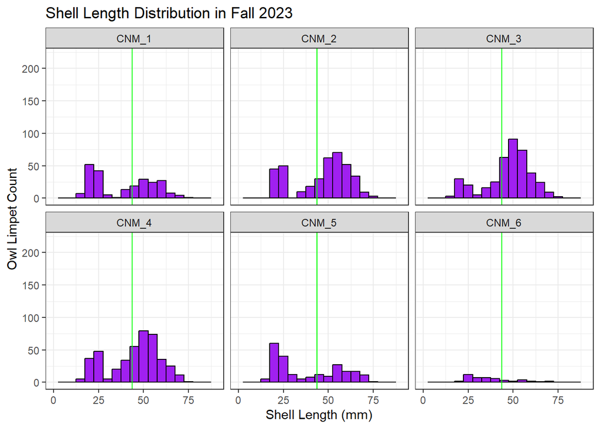

```r
sep_cnm_pop_density <- Fall_data %>% #calling df with shell length data
  ggplot( aes(x=SL_mm)) + #Sl on x, I am not selecting y so R can use limpet count for density plot
  geom_histogram(fill="purple",#color of bars
           colour="black",#color of bar outline
           alpha= 1,#transparency of bar
           binwidth = 5)+#size of bin
  labs(title = "Shell Length Distribution in Fall 2023",
       x = "Shell Length (mm)",
       y = "Owl Limpet Count")+
  theme(axis.title.y = element_blank(),
        axis.title.x = element_text(size = 10),
        axis.text.x = element_text(size = 9),
        axis.text.y = element_blank())+
  scale_x_continuous(limits = c(0,90))+ #lines I want to show up on x axis
  scale_y_continuous(limits = c(0,220))+ #lines I want to show up on y axis
  geom_vline(xintercept = mean(Fall_data$SL_mm),
             colour="green")+ #draw line where average lies on density
  theme_bw()+
  facet_wrap(~Plot_Name)
 sep_cnm_pop_density
```

# Winter Distribution

When I attempt to use geom_bar with scale_x and scale_y continous, it ommits data at certain Shell lenghts

```r
Winter_data <- filter(master_sl, Season == "Winter",
                      Date != "2023_12_10")

Winter_SL_mean <- mean(Winter_data$SL_mm)

max(Winter_data$SL_mm)
```

```
## [1] 79
```

```r
min(Winter_data$SL_mm)
```

```
## [1] 15
```

```r
median(Winter_data$SL_mm)
```

```
## [1] 48
```

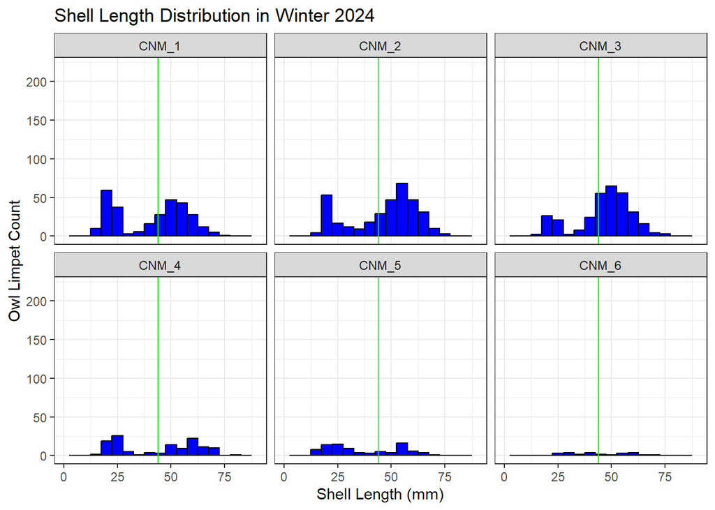

```r
Winter_pop_density <- Winter_data %>%
  ggplot( aes(x=SL_mm)) + #Sl on x, I am not selecting y so R can use limpet count for density plot
  geom_histogram(fill="blue",#color of bars
           colour="black",#color of bar outline
           alpha= 1, #transparency of bar
           binwidth = 5)+ #bin size
  labs(title = "Shell Length Distribution in Winter 2024",
         x = "Shell Length (mm)",
       y = "Owl Limpet Count")+
  theme(axis.title.y = element_blank(),
        axis.title.x = element_text(size = 10),
        axis.text.x = element_text(size = 9),
        axis.text.y = element_blank())+
  scale_x_continuous(limits = c(0,90))+ #lines I want to show up on x axis
  scale_y_continuous(limits = c(0,220))+ #lines I want to show up on y axis
  geom_vline(xintercept = mean(Winter_data$SL_mm),
             colour="green")+ #draw line where average lies on density
  theme_bw()+
  facet_wrap(~Plot_Name)

 Winter_pop_density
```

# Spring Distribution

```r
Spring_data <- filter(master_sl, Season == "Late_Spring")

Spring_SL_mean <- mean(Spring_data$SL_mm)

max(Spring_data$SL_mm)
```

```
## [1] 78.63
```

```r
min(Spring_data$SL_mm)
```

```
## [1] 15.11
```

```r
median(Spring_data$SL_mm)
```

```
## [1] 43.25
```

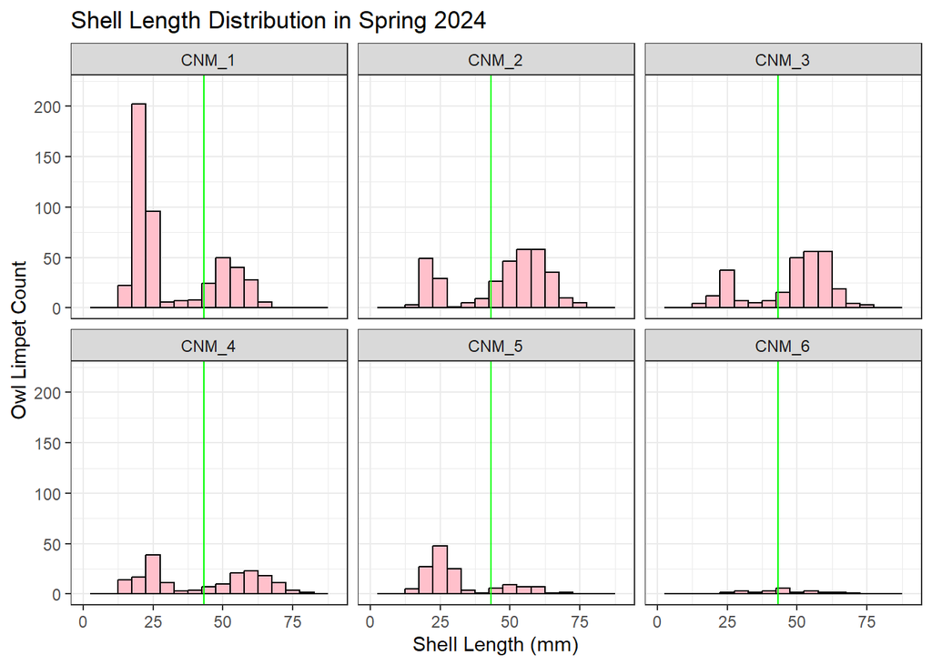

```r
spring_pop_density <- Spring_data %>% #calling df with shell length data
  ggplot( aes(x=SL_mm)) + #Sl on x, I am not selecting y so R can use limpet count for density plot
  geom_histogram(fill="pink",#color of bars
           colour="black",#color of bar outline
           alpha= 1,#transparency of bar
           binwidth = 5) + #size of bars
  labs(title = "Shell Length Distribution in Spring 2024",
       x = "Shell Length (mm)",
       y = "Owl Limpet Count")+
  theme(axis.title.y = element_blank(),
        axis.title.x = element_text(size = 10),
        axis.text.x = element_text(size = 9),
        axis.text.y = element_blank())+
  scale_x_continuous(limits = c(0,90))+
  scale_y_continuous(limits = c(0,220))+
  geom_vline(xintercept = median(Spring_data$SL_mm),
             colour="green")+ #draw line where average lies on density
  theme_bw()+
  facet_wrap(~Plot_Name)
 spring_pop_density
```

# Population Shell Length Distribution Data of All Seasons

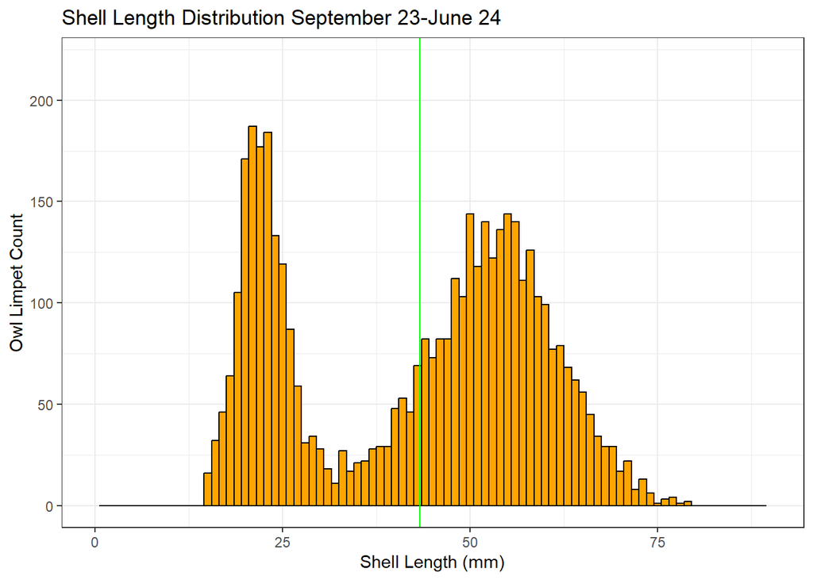

```r
#Data Manipulation
size_dist_all_seasons <-master_sl %>%
  filter(Season!="Spring",
         Date!="2023_12_10")


#anova_results <- aov(mean_sl ~ Season, data = shell_lenght_mean_per_seas)
#summary(anova_results)
#anova(anova_results)

#this a histogram with all of the shell lengths recorded for all three seasons
all_seas_hist <- size_dist_all_seasons %>% #calling df with shell length data
  ggplot( aes(x=SL_mm)) + #Sl on x, I am not selecting y so R can use limpet count for density plot
  geom_histogram(fill="orange",#color of bars
           colour="black",#color of bar outline
           alpha= 1,#transparency of bar
           binwidth = 1) + #size of bars
  labs(title = "Shell Length Distribution September 23-June 24",
       x = "Shell Length (mm)",
       y = "Owl Limpet Count")+
  theme(axis.title.y = element_blank(),
        axis.title.x = element_text(size = 10),
        axis.text.x = element_text(size = 9),
        axis.text.y = element_blank())+
  scale_x_continuous(limits = c(0,90))+
  scale_y_continuous(limits = c(0,220))+
  geom_vline(xintercept = median(Spring_data$SL_mm),
             colour="green")+ #draw line where average lies on density
  theme_bw()#+
  #facet_wrap(~Plot_Name)
 #spring_pop_density
all_seas_hist
```

[figure not shown]

```r
all_seasons_sl_boxplot <- ggplot(size_dist_all_seasons,
                                   aes(x=Season,
                                       y=SL_mm,
                                       fill=Season))+
  geom_boxplot(width = 0.7,
               show.legend = FALSE)+
  labs(title = "Shell Length Distribution of Owl Limpets per Season",
       x = "Season",
       y ="Shell Length")+
  scale_y_continuous(breaks = c(20,30,40,50,60,70,80,90))+
  scale_x_discrete(labels=c("Fall","Winter","Spring"))+
  scale_color_brewer(palette = "Set2")+
  scale_fill_brewer(palette = "Set3")+
  theme_bw()
all_seasons_sl_boxplot
```

# Median graph

[figure not shown]

```r
shell_lenght_stats_per_seas <- size_dist_all_seasons %>%
  group_by(Season) %>%
  summarise(mean_sl = mean(SL_mm),
            var_sl = var(SL_mm),
            sd_sl = sd(SL_mm),
            n_sl= n(),# Get the sample size for the group
            se_sl = sd_sl / sqrt(n_sl),
            med_sl = median(SL_mm),
            min_sl = min(SL_mm),
            max_sl = max(SL_mm)) %>%
  mutate(Seasons = as.factor(Season))

sl_med_SE <- ggplot(shell_lenght_stats_per_seas,
                    aes(x = Seasons,
                        y = med_sl))+
  geom_point(show.legend = FALSE,
             size = 5)+ #this adds the point where the median is
  geom_errorbar(aes(ymin = mean_sl - sd_sl, ymax = mean_sl + sd_sl),
                   width = 0.2,
                show.legend = FALSE)+ #this add the error line which is the mean of the shell length +/- the standard deviation
  geom_jitter(data = size_dist_all_seasons,
              aes(x = Season,
                  y = SL_mm),
              alpha = 0.1,
              width = 0.15,
              color = "purple",
              show.legend = FALSE)+
  labs(title = "Median and Standard Error  of Shell Length Distribution",
       x = "Season",
       y ="Shell Length",
       axis.title.x = element_text(18))+
  scale_x_discrete(labels=c("Fall","Spring","Winter"))+
  #scale_colour_brewer(palette = "Set3")
  theme_bw()+
  theme(axis.text.x = element_text(size = 15),
        axis.title.x = element_text(size = 18, face = "bold"),
       axis.title.y = element_text(size = 18, face = "bold"))
sl_med_SE
```

# Analysis of Shell Length Distribution For all seasons

Here I begin the analysis of the shell length distribution to see if they’re significantly different between seasons.

```r
#models
SL_dis_mod <- kruskal.test(SL_mm~Season, data=size_dist_all_seasons)
#check_model(SL_dis_mod) #this disn't work, I got this error
#Error: `check_model()` returned following error: Can't extract variance-covariance matrix. `get_varcov()` returned following
  #error: no applicable method for 'vcov' applied to an object of class "htest"
  #If the error message does not help identifying your problem, another reason why `check_model()` failed might be that
  #models of class `htest` are not yet supported.


shapiro.test(size_dist_all_seasons$SL_mm)
```

```
##
##  Shapiro-Wilk normality test
##
## data:  size_dist_all_seasons$SL_mm
## W = 0.9154, p-value < 2.2e-16
```

```r
pairwise.wilcox.test(size_dist_all_seasons$SL_mm, size_dist_all_seasons$Season,
                 p.adjust.method = "BH")
```

```
##
##  Pairwise comparisons using Wilcoxon rank sum test with continuity correction
##
## data:  size_dist_all_seasons$SL_mm and size_dist_all_seasons$Season
##
##             Fall    Late_Spring
## Late_Spring 6.5e-07 -
## Winter      0.54    7.1e-07
##
## P value adjustment method: BH
```

```r
dunnTest(SL_mm~Season,
         size_dist_all_seasons,
         method="bonferroni")
```

```
##             Comparison          Z      P.unadj        P.adj
## 1   Fall - Late_Spring  5.0995940 3.403828e-07 1.021148e-06
## 2        Fall - Winter -0.5089298 6.108015e-01 1.000000e+00
## 3 Late_Spring - Winter -5.1481208 2.631090e-07 7.893270e-07
```

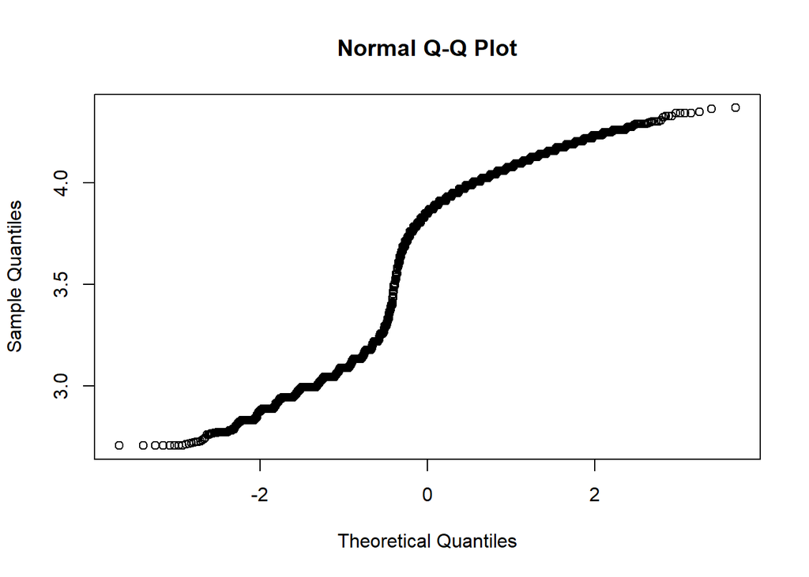

```r
log_size_dist_all_seasons <-master_sl %>%
  filter(Season!="Spring",
         Date!="2023_12_10") %>%
  mutate(log_sl= log(SL_mm),
         sqr_sl= sqrt(SL_mm))

qqnorm(log_size_dist_all_seasons$log_sl)
```

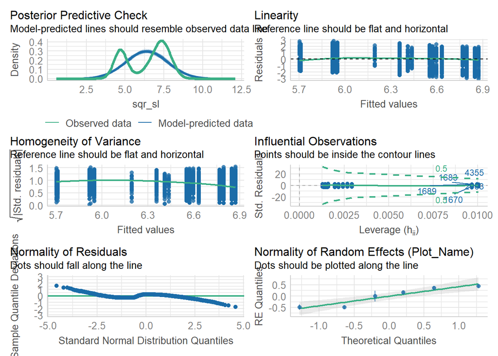

```r
#lmer
sl_lmer<-lmer(sqr_sl~Season+(1|Plot_Name), data = log_size_dist_all_seasons)
check_model(sl_lmer)
```

```r
summary(sl_lmer)
```

```
## Linear mixed model fit by REML. t-tests use Satterthwaite's method [
## lmerModLmerTest]
## Formula: sqr_sl ~ Season + (1 | Plot_Name)
##    Data: log_size_dist_all_seasons
##
## REML criterion at convergence: 14325.5
##
## Scaled residuals:
##     Min      1Q  Median      3Q     Max
## -2.4104 -0.9019  0.2164  0.7986  2.2906
##
## Random effects:
##  Groups    Name        Variance Std.Dev.
##  Plot_Name (Intercept) 0.1685   0.4105
##  Residual              1.5486   1.2444
## Number of obs: 4364, groups:  Plot_Name, 6
##
## Fixed effects:
##                     Estimate Std. Error         df t value Pr(>|t|)
## (Intercept)          6.40628    0.17117    5.29541  37.427 1.26e-07 ***
## SeasonLate_Spring   -0.21532    0.04557 4359.92229  -4.725 2.38e-06 ***
## SeasonWinter         0.02566    0.04776 4359.33394   0.537    0.591
## ---
## Signif. codes:  0 '***' 0.001 '**' 0.01 '*' 0.05 '.' 0.1 ' ' 1
##
## Correlation of Fixed Effects:
##             (Intr) SsnL_S
## SsnLt_Sprng -0.117
## SeasonWintr -0.110  0.452
```

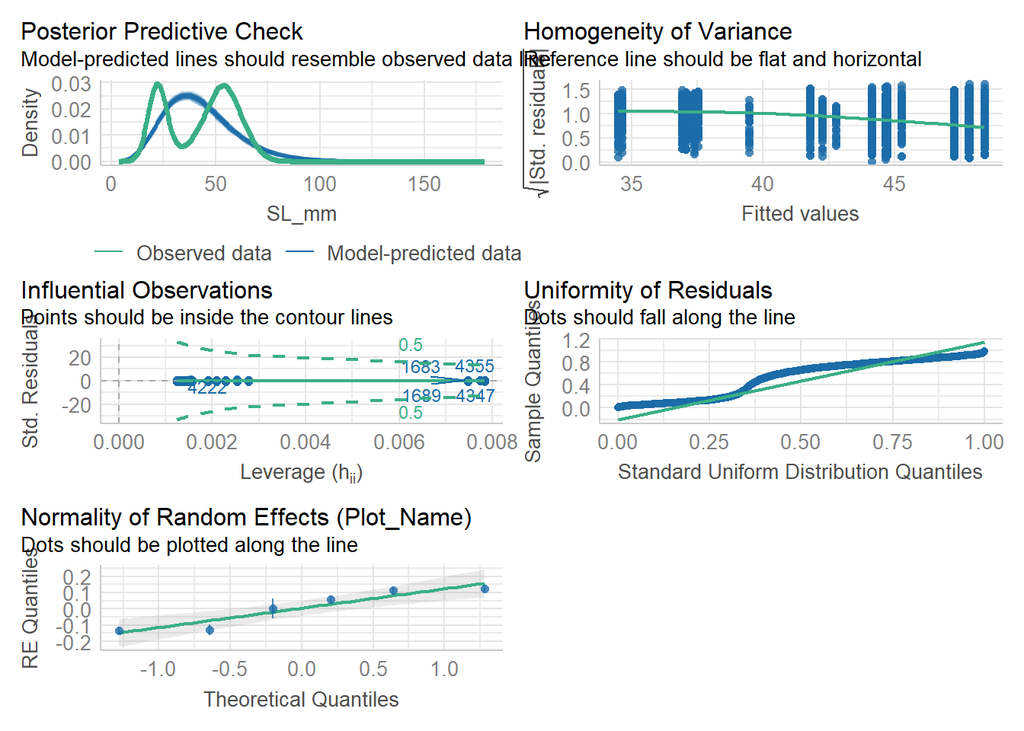

```r
#glmer with family gamma because shell length is continuous
sl_glm<-glmer(SL_mm~Season+(1|Plot_Name), data = log_size_dist_all_seasons,
             family = Gamma(link="log"))
check_model(sl_glm)
```

```r
anova(sl_glm)
```

```
## Analysis of Variance Table
##        npar Sum Sq Mean Sq F value
## Season    2 5.1709  2.5854  18.365
```

```r
summary(sl_glm)
```

```
## Generalized linear mixed model fit by maximum likelihood (Laplace
##   Approximation) [glmerMod]
##  Family: Gamma  ( log )
## Formula: SL_mm ~ Season + (1 | Plot_Name)
##    Data: log_size_dist_all_seasons
##
##      AIC      BIC   logLik deviance df.resid
##  36499.4  36531.3 -18244.7  36489.4     4359
##
## Scaled residuals:
##     Min      1Q  Median      3Q     Max
## -1.8392 -0.9974  0.1363  0.7659  2.8926
##
## Random effects:
##  Groups    Name        Variance Std.Dev.
##  Plot_Name (Intercept) 0.002874 0.05361
##  Residual              0.140783 0.37521
## Number of obs: 4364, groups:  Plot_Name, 6
##
## Fixed effects:
##                   Estimate Std. Error t value Pr(>|z|)
## (Intercept)        3.74352    0.05074  73.774  < 2e-16 ***
## SeasonLate_Spring -0.06817    0.01435  -4.751 2.02e-06 ***
## SeasonWinter       0.01237    0.01514   0.817    0.414
## ---
## Signif. codes:  0 '***' 0.001 '**' 0.01 '*' 0.05 '.' 0.1 ' ' 1
##
## Correlation of Fixed Effects:
##             (Intr) SsnL_S
## SsnLt_Sprng -0.125
## SeasonWintr -0.118  0.455
```

# Post_hoc test for Shell Length Distributions

```r
#Post hoc tests
emmeans(sl_glm, list(pairwise~Season), adjust = "tukey")
```

```
## $`emmeans of Season`
##  Season      emmean     SE  df asymp.LCL asymp.UCL
##  Fall          3.74 0.0507 Inf      3.64      3.84
##  Late_Spring   3.68 0.0510 Inf      3.58      3.78
##  Winter        3.76 0.0512 Inf      3.66      3.86
##
## Results are given on the log (not the response) scale.
## Confidence level used: 0.95
##
## $`pairwise differences of Season`
##  1                    estimate     SE  df z.ratio p.value
##  Fall - Late_Spring     0.0682 0.0143 Inf   4.751  <.0001
##  Fall - Winter         -0.0124 0.0151 Inf  -0.817  0.6928
##  Late_Spring - Winter  -0.0805 0.0154 Inf  -5.225  <.0001
##
## Results are given on the log (not the response) scale.
## P value adjustment: tukey method for comparing a family of 3 estimates
```

# Big or Small Limpets For All Seasons and Individual Seasons

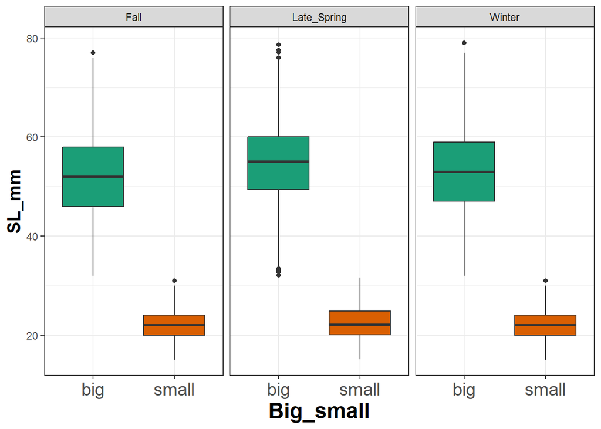

```r
big_small_for_all_seasons <- master_sl %>%
  filter(Season!="Spring",
         Date!="2023_12_10") %>%
  mutate(Big_small=ifelse(SL_mm>= 32, "big", "small"))

all_seas_big_small_density_plot <- ggplot(big_small_for_all_seasons,
                                   aes(x=Big_small,
                                       y=SL_mm,
                                       fill = Big_small))+
  geom_boxplot(show.legend = FALSE)+
  scale_fill_brewer(palette = "Dark2")+
  theme_bw()+
  theme(axis.text.x = element_text(size = 15),
        axis.title.x = element_text(size = 18, face = "bold"),
       axis.title.y = element_text(size = 15, face = "bold"))+
  facet_wrap(~Season)

all_seas_big_small_density_plot
```

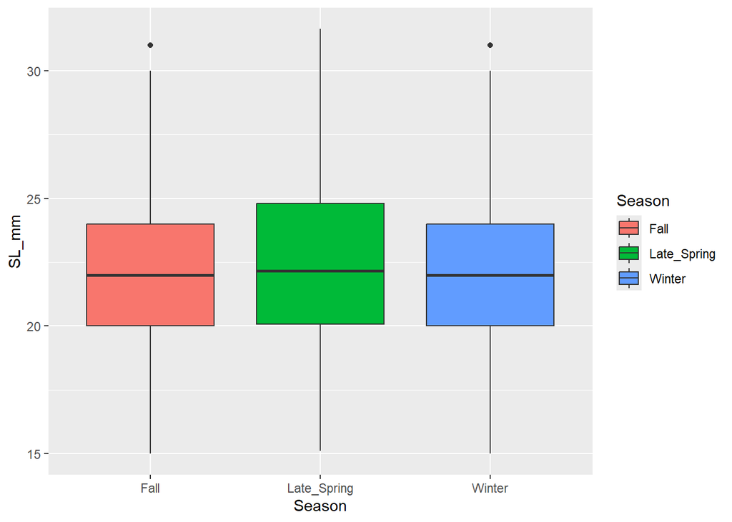

```r
only_smalls <- big_small_for_all_seasons %>%
  filter(Big_small!="big")

only_smalls_boxplot <- ggplot(only_smalls,
                              aes(x=Season,
                                  y = SL_mm,
                                  fill = Season))+
  geom_boxplot()
only_smalls_boxplot
```

# Population Density

In this section I will look at the population density throughout the seasons and their statistical analysis.

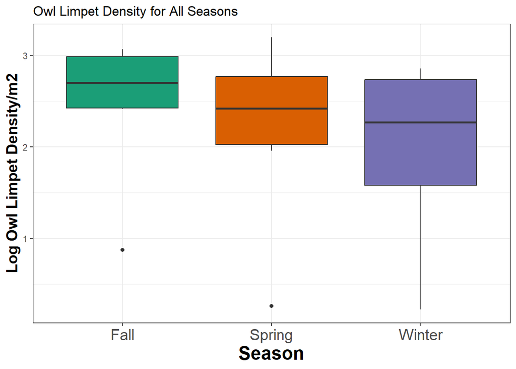

```r
all_seasons_Density_Data <- master_sl %>%
   filter(Season!="Spring", #not including re-tagging event
          Date!="2023_12_10")  %>% #not including December
   group_by(Season, Plot_Name) %>%
   count()%>%
   mutate(limpet_density_m2 = n/20) %>%
  mutate(Plot = as.factor(Plot_Name)) %>%
  mutate(log_density = log(limpet_density_m2),
         Seasons = as.factor(Season))

all_seasons_density_plot <- ggplot(all_seasons_Density_Data,
                                   aes(x=Season,
                                       y=log_density,
                                       fill=Season))+
  geom_boxplot(show.legend = FALSE)+
  labs(title = "Owl Limpet Density for All Seasons",
       x = "Season",
       y ="Log Owl Limpet Density/m2")+
  scale_x_discrete(labels=c("Fall","Spring","Winter"))+
  scale_fill_brewer(palette = "Dark2")+
  theme_bw()+
  theme(axis.text.x = element_text(size = 15),
        axis.title.x = element_text(size = 18, face = "bold"),
       axis.title.y = element_text(size = 15, face = "bold"))

all_seasons_density_plot
```

# Linear mixed effects model for population density

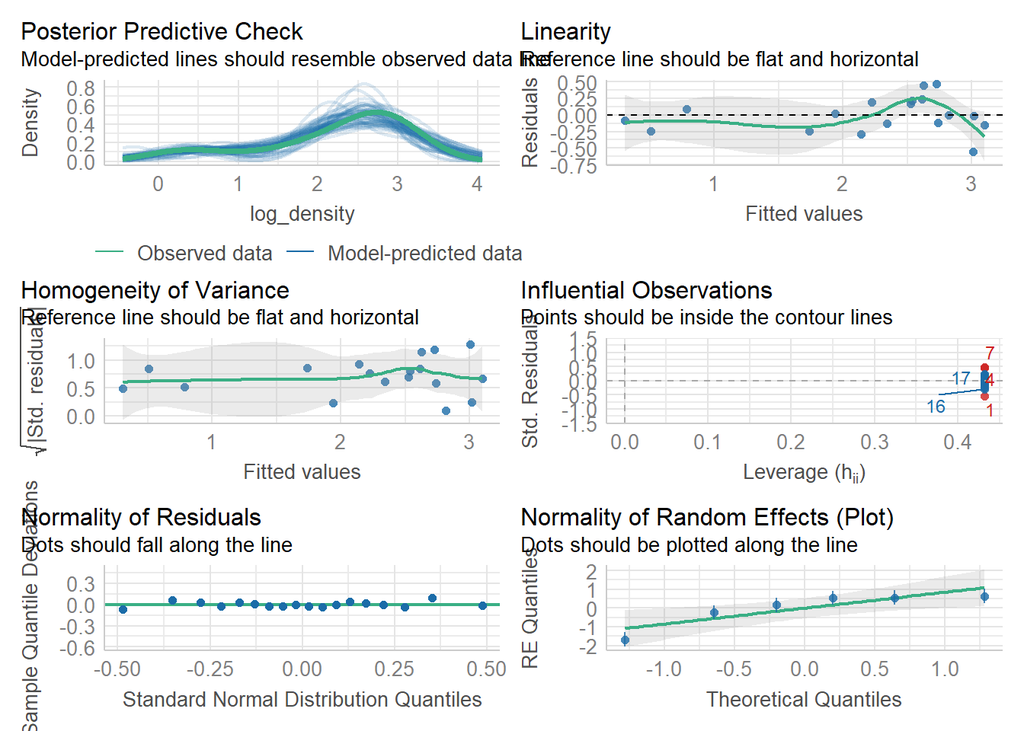

```r
# run model for dependent variable ~ independent, then for normality, etc, interpret model
mod_density_all_seasons <-lmer(log_density~Season+(1|Plot), data = all_seasons_Density_Data)
check_model(mod_density_all_seasons)
```

```r
anova(mod_density_all_seasons)
```

```
## Type III Analysis of Variance Table with Satterthwaite's method
##         Sum Sq Mean Sq NumDF DenDF F value  Pr(>F)
## Season 0.70507 0.35253     2    10  3.0918 0.09008 .
## ---
## Signif. codes:  0 '***' 0.001 '**' 0.01 '*' 0.05 '.' 0.1 ' ' 1
```

```r
summary(mod_density_all_seasons)
```

```
## Linear mixed model fit by REML. t-tests use Satterthwaite's method [
## lmerModLmerTest]
## Formula: log_density ~ Season + (1 | Plot)
##    Data: all_seasons_Density_Data
##
## REML criterion at convergence: 30.9
##
## Scaled residuals:
##      Min       1Q   Median       3Q      Max
## -1.65118 -0.41915 -0.03486  0.55356  1.38809
##
## Random effects:
##  Groups   Name        Variance Std.Dev.
##  Plot     (Intercept) 0.8179   0.9044
##  Residual             0.1140   0.3377
## Number of obs: 18, groups:  Plot, 6
##
## Fixed effects:
##                   Estimate Std. Error      df t value Pr(>|t|)
## (Intercept)         2.4598     0.3941  5.9042   6.241 0.000833 ***
## SeasonLate_Spring  -0.2807     0.1950 10.0000  -1.440 0.180549
## SeasonWinter       -0.4827     0.1950 10.0000  -2.476 0.032780 *
## ---
## Signif. codes:  0 '***' 0.001 '**' 0.01 '*' 0.05 '.' 0.1 ' ' 1
##
## Correlation of Fixed Effects:
##             (Intr) SsnL_S
## SsnLt_Sprng -0.247
## SeasonWintr -0.247  0.500
```

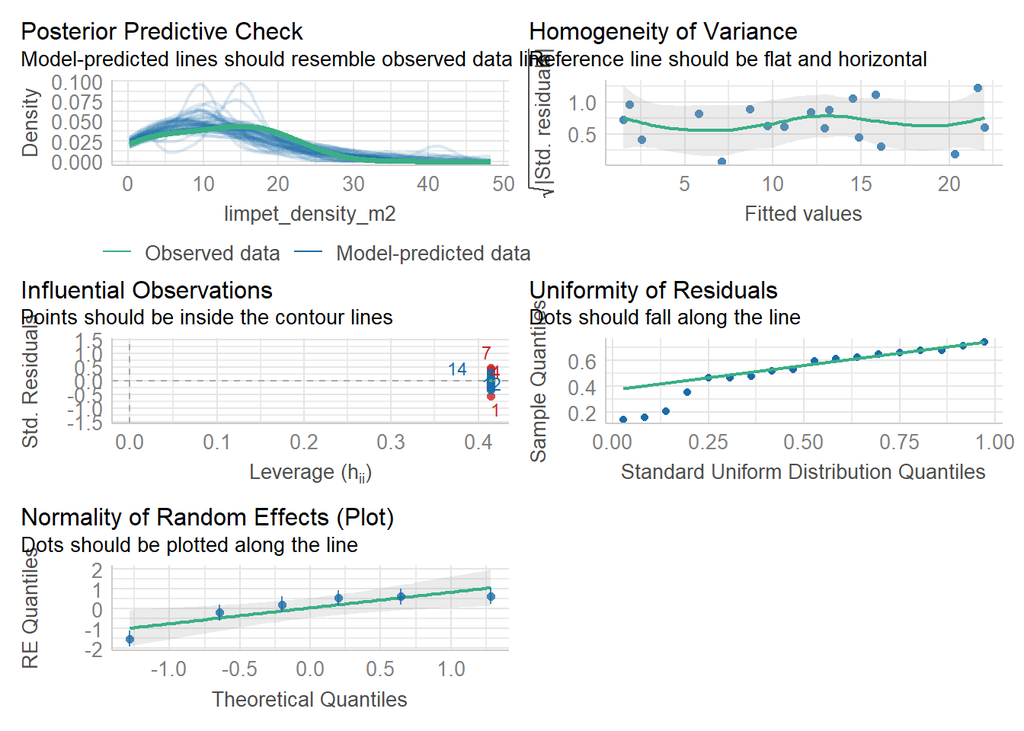

```r
#i'm going to stick to the generalized mixed effects model because the data is not normally distributed and the data is continous.
#glmm
density_glmm <- glmer(limpet_density_m2 ~ Season + (1 |Plot),
                    data = all_seasons_Density_Data,
                    family = Gamma(link = "log"))
check_model(density_glmm)
```

```r
anova(density_glmm)
```

```
## Analysis of Variance Table
##        npar  Sum Sq Mean Sq F value
## Season    2 0.80005 0.40003    2.84
```

```r
summary(density_glmm)
```

```
## Generalized linear mixed model fit by maximum likelihood (Laplace
##   Approximation) [glmerMod]
##  Family: Gamma  ( log )
## Formula: limpet_density_m2 ~ Season + (1 | Plot)
##    Data: all_seasons_Density_Data
##
##      AIC      BIC   logLik deviance df.resid
##    109.5    114.0    -49.8     99.5       13
##
## Scaled residuals:
##     Min      1Q  Median      3Q     Max
## -1.2345 -0.4615 -0.1024  0.4074  1.4516
##
## Random effects:
##  Groups   Name        Variance Std.Dev.
##  Plot     (Intercept) 0.3856   0.6209
##  Residual             0.1409   0.3753
## Number of obs: 18, groups:  Plot, 6
##
## Fixed effects:
##                   Estimate Std. Error t value Pr(>|z|)
## (Intercept)         2.4690     0.4651   5.309  1.1e-07 ***
## SeasonLate_Spring  -0.3116     0.1555  -2.004 0.045067 *
## SeasonWinter       -0.5124     0.1553  -3.301 0.000964 ***
## ---
## Signif. codes:  0 '***' 0.001 '**' 0.01 '*' 0.05 '.' 0.1 ' ' 1
##
## Correlation of Fixed Effects:
##             (Intr) SsnL_S
## SsnLt_Sprng -0.168
## SeasonWintr -0.168  0.513
```

# Post Hoc test for population density

```r
#Post hoc tests
emmeans(density_glmm, list(pairwise~Season), adjust = "tukey")
```

```
## $`emmeans of Season`
##  Season      emmean    SE  df asymp.LCL asymp.UCL
##  Fall          2.47 0.465 Inf      1.56      3.38
##  Late_Spring   2.16 0.465 Inf      1.25      3.07
##  Winter        1.96 0.465 Inf      1.05      2.87
##
## Results are given on the log (not the response) scale.
## Confidence level used: 0.95
##
## $`pairwise differences of Season`
##  1                    estimate    SE  df z.ratio p.value
##  Fall - Late_Spring      0.312 0.155 Inf   2.004  0.1112
##  Fall - Winter           0.512 0.155 Inf   3.301  0.0028
##  Late_Spring - Winter    0.201 0.153 Inf   1.310  0.3896
##
## Results are given on the log (not the response) scale.
## P value adjustment: tukey method for comparing a family of 3 estimates
```

# Plots for Owl Limper Abundance

[figure not shown]

```r
all_seasons_abundance_Data <- master_sl %>%
   filter(Season!="Spring", #not including re-tagging event
          Date!="2023_12_10")  %>% #not including December
   group_by(Season, Plot_Name) %>%
   count() %>%
  mutate(Plot = as.factor(Plot_Name)) %>%
  mutate(log_abundance = log(n),
          Seasons = as.factor(Season))

all_seasons_abundance_plot <- ggplot(all_seasons_abundance_Data,
                                   aes(x=Season,
                                       y=log_abundance,
                                       fill=Season))+
  geom_boxplot(show.legend = FALSE)+
  labs(title= "Owl Limpet Population Abundance for All Seasons",
       x = "Season",
       y ="Log Owl Limpet Abundance")+
  scale_x_discrete(labels=c("Fall","Winter","Spring"))+
  scale_fill_brewer(palette = "Accent")+
  theme_bw()

all_seasons_abundance_plot
```

# Linear models for Owl limpets Abundance per season

```r
#linear_abundance <-master_sl %>%
   #filter(Season!="Spring",
          #Date!="2023_12_10") %>%  #not including December
   #group_by(Season, Plot_Name) %>%
   #count()

#abun_mod <- kruskal.test(n~Season, data=linear_abundance)
#dunnTest(n~Season,
 #        linear_abundance,
  #       method="bonferroni")

#shapiro.test(linear_abundance$abun)

#mixed effects linear regressions
#mod_abundance_all_seasons <-lmer(n~Season+(1|Plot_Name), data = linear_abundance)
#check_model(mod_abundance_all_seasons)
#anova(mod_abundance_all_seasons)
#summary(mod_abundance_all_seasons)

#Post hoc tests
#emmeans(mod_abundance_all_seasons, list(pairwise~Season), adjust = "tukey")

#using glmer because i am using transect as a random effect. I am using poisson distribution with log link because data is not normally distributed, even after transforming
#glmm
#abun_per_seas_tran <-glmer(n~Season+(1|Plot_Name), data = linear_abundance,family = poisson(link = "log"))
#check_model(abun_per_seas_tran)
#anova(abun_per_seas_tran)
#summary(mod_abundance_all_seasons)
```

# Post Hoc test for Owl Limpet Abundance

```r
#Post hoc test
#emmeans(abun_per_seas_tran, list(pairwise~Season), adjust = "tukey")
```

# MANOVA or perMANOVA of Seasons x Shell Length, Density, Abundance

```r
#FIX THIS CHUNK
#average_data <-master_sl %>%
  #filter(Season!="Spring",
        # Date!="2023_12_10") %>%
  #group_by(Season, Plot_Name)

#manova_data <-master_sl %>%
   #filter(Season!="Spring", #not including re-tagging event
          #Date!="2023_12_10") %>% #not including December
   #group_by(Season, Plot_Name)%>%
   #count()%>%
   #mutate(limpet_density_m2 = n/20) %>%
  #mutate(Plot = as.factor(Plot_Name)) %>%
  #mutate(log_density = log(limpet_density_m2)) %>%
  #ungroup() %>%
  #group_by(Season) %>%
  #mutate(abun = sum(n)) %>%
  #ungroup() %>%
  #group_by(Season, Plot_Name) %>%
  #mutate(SL_avg = mean(average_data$SL_mm))


  #left_join(size_dist_all_seasons, by="Plot_Name") %>%
  #group_by(Season.x, Plot) %>%
  #mutate(SL_avg = mean(SL_mm))
```

# Cabrillo Yearly Data

This Data came from Lauren Pandori. This data in the owl limpet size recorded in all zones from 1990-2021. In this manipulation, I filtered for only Zone III data since I worked in Zone III. I am attempting to see if the there is a dip in the count data at a specific size frame that matches or closely matches my data to see if there is a pattern in size distribution.

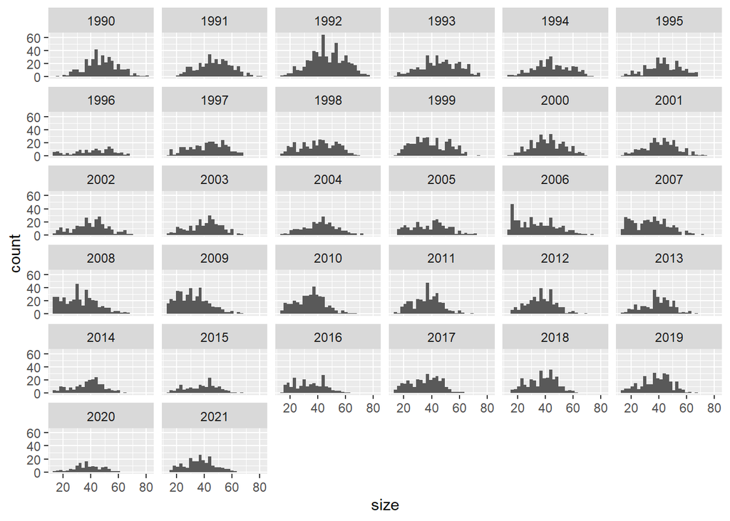

```r
CNM_ZThree__yearly_data <- cabrillo_yearly_lim_size %>%
  filter(zone=="Zone III") %>%
  group_by(survey_year, season_name) %>%
  reframe(size=rep(size_class,n)) #%>%
  #filter(survey_year=="1990") this will filter per year to see if there is a dip like my data

CNM_ZThree__yearly_data %>%
  ggplot(aes(x = size))+
  geom_histogram()+
  facet_wrap(~survey_year)
```

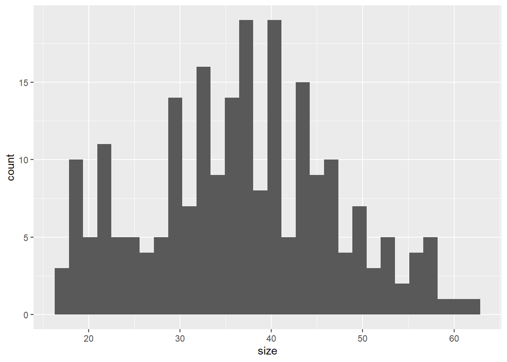

```r
#Use this to look at Cabrillo Data Per Year
CNM_ZThree_per_year_data <- CNM_ZThree__yearly_data%>%
  filter(survey_year=="2021") #change this to match the year you are looking for

CNM_ZThree_per_year_data %>%
  ggplot(aes(x = size))+
  geom_histogram()
```

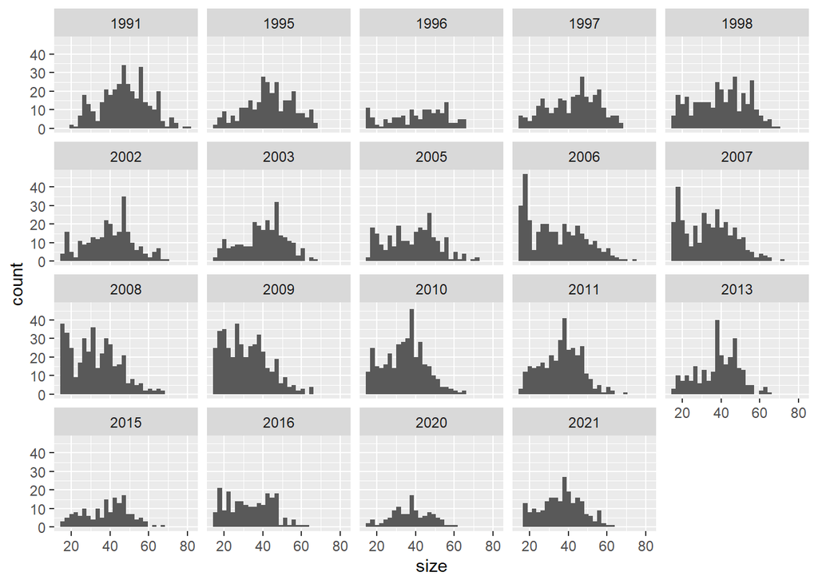

```r
dip_CNM_ZThree_per_year_data <- CNM_ZThree__yearly_data %>%
  filter(survey_year %in% c("1991","1995","1996","1997","1998","2002","2003","2005","2006","2007","2008","2009","2010","2011","2013","2015","2016","2020","2021"))#change this to match the year you are looking for

dip_CNM_ZThree_per_year_data %>%
  ggplot(aes(x = size))+
  geom_histogram()+
  facet_wrap(~survey_year)
```

# Community Survey Data Manipulation

```r
#lets start with manipulating mobile data. I need to make the mobile data sheet long and add another column specifying the functionality of the mobile organism (herbivore, carnivore)

#When after mutating the sum the number of individuals, I get a new row called spec_sum which gives me the total number of individuals of all species into one column/transect. For instance, in plot name CNM_1_C_5, spec_sum adds all of the number across that row, so the sum is 2. If I pivot longer, species sum, which corresponds to one transect on either a yes or no plot, shows up often making it difficult to visualize. I might need to sperate the data by seasons to view the species sum by transect

long_mobiles <- mobiles_master %>%
  group_by(Season) %>%
  mutate(spec_sum = rowSums(across(c(M_lugubris, L_hartwegii, L_dentiens, L_plena, L_keenae, L_limatula, L_scabra, Nuttallina_sp, Mopalia_sp, P_crassipes, T_eiseni, T_funebralis, T_gallina, L_gigantea)), na.rm=TRUE)) %>%
  pivot_longer(cols = M_lugubris:L_gigantea,
               names_to = "species",
               values_to = "count") %>%
  mutate(species = as.factor(species)) %>%
  mutate(functionality = case_when(
  species %in% "M_lugubris" ~ "carnivore",
  species %in% "L_hartwegii" ~ "macrograzer",
  species %in%  "L_dentiens" ~ "macrograzer",
  species %in%  "L_plena" ~ "mesograzer",
  species %in%  "L_keenae" ~ "mesograzer",
  species %in%  "L_limatula" ~ "macrograzer",
  species %in%  "L_scabra" ~ "macrograzer",
  species %in%  "Nuttallina_sp" ~ "macrograzer",
  species %in%  "Mopalia_sp" ~ "mesograzer",
  species %in%  "P_crassipes" ~ "omnivore",
  species %in%  "T_eiseni" ~ "mesograzer",
  species %in%  "T_funebralis" ~ "mesograzer",
  species %in%  "T_gallina" ~ "mesograzer",
  species %in%  "L_gigantea" ~ "mesograzer"))
```

# Summary of mobiles

```r
summary_mobiles <- long_mobiles %>%
  mutate(log_count = log(count+1)) %>%
  group_by(functionality, Season, COL_pres) %>%
  summarize(mean_count = mean(log_count, na.rm = TRUE),
          se_count = sd(log_count, na.rm = TRUE)/sqrt(n()))
summary_mobiles
```

```
## # A tibble: 24 × 5
## # Groups:   functionality, Season [12]
##    functionality Season COL_pres mean_count se_count
##    <chr>         <chr>  <chr>         <dbl>    <dbl>
##  1 carnivore     Fall   NO           0.0193   0.0193
##  2 carnivore     Fall   YES          0.131    0.0693
##  3 carnivore     Spring NO           0.302    0.0753
##  4 carnivore     Spring YES          0.345    0.0691
##  5 carnivore     Winter NO           0.157    0.0585
##  6 carnivore     Winter YES          0.158    0.0652
##  7 macrograzer   Fall   NO           0.0892   0.0235
##  8 macrograzer   Fall   YES          0.0951   0.0255
##  9 macrograzer   Spring NO           0.191    0.0337
## 10 macrograzer   Spring YES          0.156    0.0287
## # ℹ 14 more rows
```

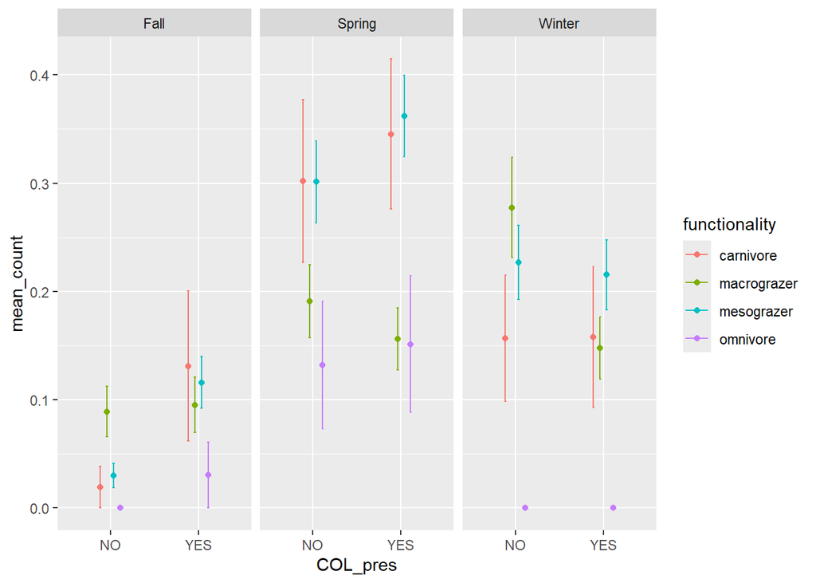

```r
summary_plot <- summary_mobiles %>%
  ggplot(aes(x = COL_pres,
             y = mean_count,
             color = functionality))+
  geom_point(position = position_dodge(width = 0.3))+ #this code helps spread apart the error bars
  geom_errorbar(aes(ymin=mean_count-se_count, ymax=mean_count+se_count),
               width = 0.1,
               position = position_dodge(width = 0.3))+ #this code helps spread apart the error bars
  facet_wrap(~Season)
summary_plot
```

# linear models with random effect per function

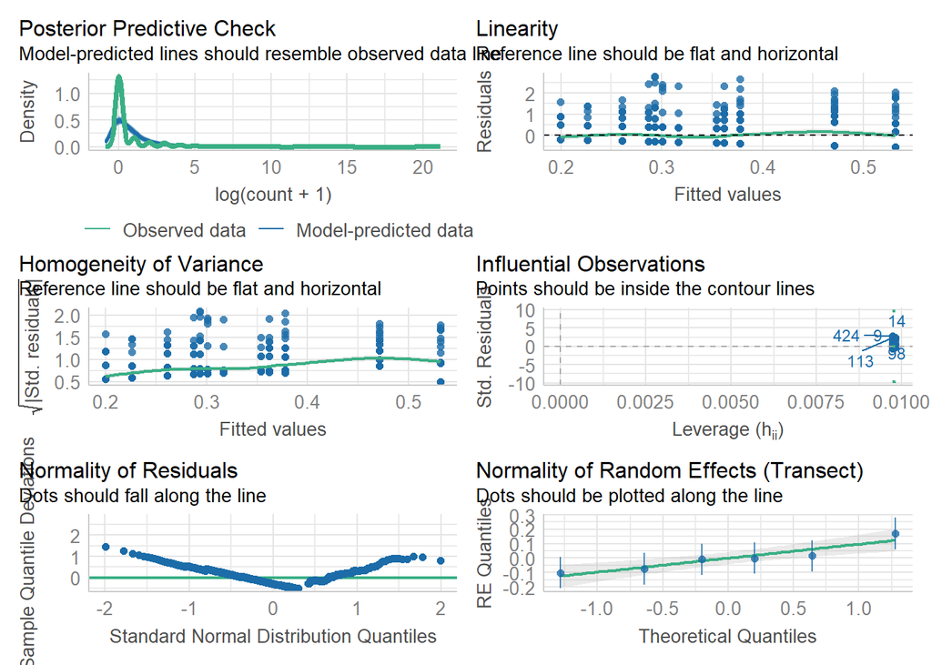

```r
meso_lm <- lmer(log(count+1)~COL_pres+(1|Transect),
                data = long_mobiles %>%
                  filter(functionality == "mesograzer", #change function
                         Season == "Spring")) #change season
check_model(meso_lm)
```

```r
ggsave(here("Output", "meso_lm_Check_Model.png"))
anova(meso_lm)
```

```
## Type III Analysis of Variance Table with Satterthwaite's method
##           Sum Sq Mean Sq NumDF  DenDF F value Pr(>F)
## COL_pres 0.54597 0.54597     1 580.01  1.3385 0.2478
```

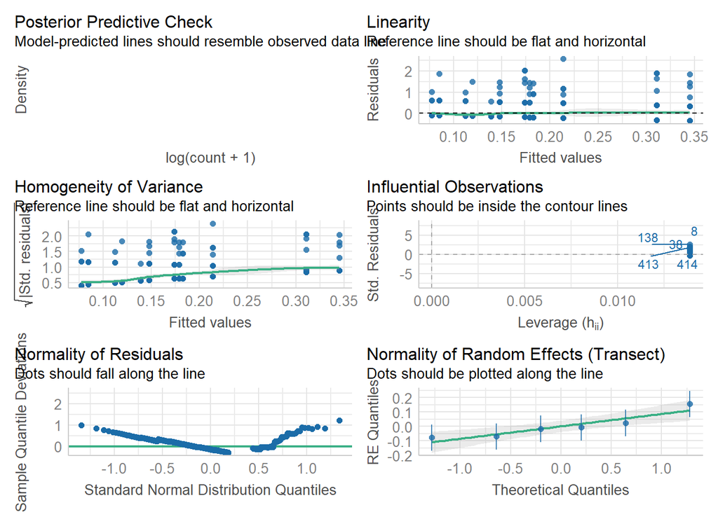

```r
#When Nyssa and I ran the mixed effects model with season as an interaction term, seasonality was so strong that if there was any effect by COL_pres it is not noticeable. So we took out season as an interaction, and filter out each season and look at the results. These are the results:
    #function mesograzer
        #Season: Fall
            #-residuals not normal, p= 0.001
        #Season: Winter
            #residuals not normal, p= 0.81
        #Season: Spring
            #residuals not normal, p= 0.25
            #Residuals are not normal. Will run glmer, family poisson, log link

macro_lm <- lmer(log(count+1)~COL_pres+(1|Transect),
                data = long_mobiles %>%
                  filter(functionality == "macrograzer", #change function
                         Season == "Spring")) #change season
check_model(macro_lm)
```

```r
ggsave(here("Output", "macro_lm_check_model.png"))
anova(macro_lm)
```

```
## Type III Analysis of Variance Table with Satterthwaite's method
##           Sum Sq Mean Sq NumDF DenDF F value Pr(>F)
## COL_pres 0.12706 0.12706     1   413  0.6414 0.4237
```

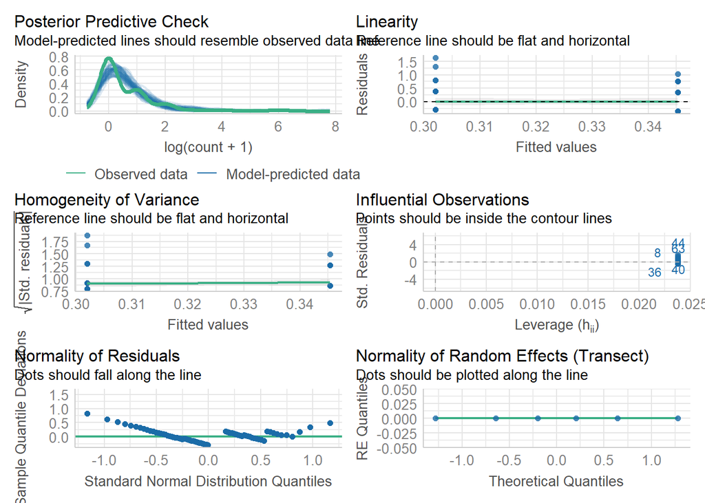

```r
#I ran the mixed effects model with season as an interaction term, seasonality was so strong that if there was any effect by COL_pres it is not noticeable. Took out season as an interaction, and filter out each season and look at the results. These are the results:
    #function macrograzer
        #Season: Fall
            #-residuals not normal, p= 0.86
        #Season: Winter
            #residuals not normal, p= 0.017
        #Season: Spring
            #residuals not normal, p= 0.42
            #Residuals are not normal. Will run glmer, family poisson, log link

carn_lm <- lmer(log(count+1)~COL_pres+(1|Transect),
                data = long_mobiles %>%
                  filter(functionality == "carnivore", #change function
                         Season == "Spring")) #change season
check_model(carn_lm)
```

```r
ggsave(here("Output", "carn_lm_Check_Model.png"))
anova(carn_lm)
```

```
## Type III Analysis of Variance Table with Satterthwaite's method
##           Sum Sq Mean Sq NumDF DenDF F value Pr(>F)
## COL_pres 0.03943 0.03943     1    82  0.1797 0.6728
```

```r
#I ran the mixed effects model with season as an interaction term, seasonality was so strong that if there was any effect by COL_pres it is not noticeable. Took out season as an interaction, and filter out each season and look at the results. These are the results:
    #function carnivore
        #Season: Fall
            #-residuals not normal, p= 0.12
        #Season: Winter
            #residuals not normal, p= 0.98
        #Season: Spring
            #residuals not normal, p= 0.67
            #Residuals are not normal. Will run glmer, family poisson, log link
```

# Generalized Linear Model Per Function, poisson log link

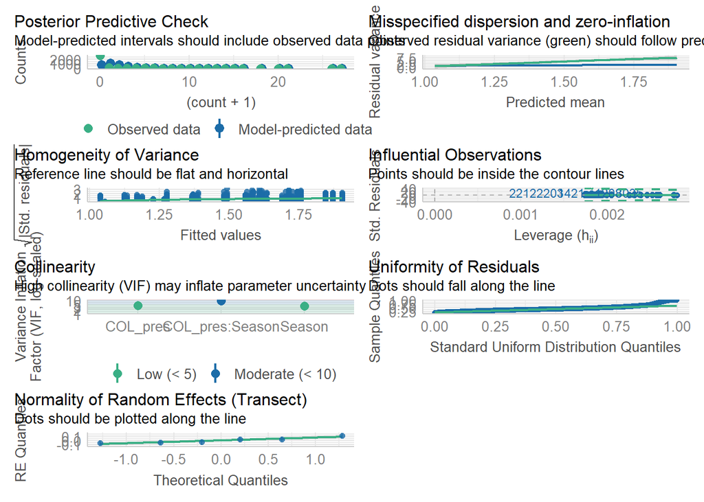

```r
meso_glmm <- glmer((count+1)~COL_pres*Season+(1|Transect),
                data = long_mobiles,
                family = poisson(link = "log")) #%>%
                  #filter(functionality == "mesograzer")) #change function
check_model(meso_glmm)
```

```r
ggsave(here("Output", "glmm_func_cm.png"))
anova(meso_glmm)
```

```
## Analysis of Variance Table
##                 npar Sum Sq Mean Sq F value
## COL_pres           1  2.989   2.989  2.9890
## Season             2 95.583  47.791 47.7914
## COL_pres:Season    2 14.823   7.411  7.4113
```

```r
summary(meso_glmm)
```

```
## Generalized linear mixed model fit by maximum likelihood (Laplace
##   Approximation) [glmerMod]
##  Family: poisson  ( log )
## Formula: (count + 1) ~ COL_pres * Season + (1 | Transect)
##    Data: long_mobiles
##
##      AIC      BIC   logLik deviance df.resid
##  10505.2  10548.1  -5245.6  10491.2     3352
##
## Scaled residuals:
##     Min      1Q  Median      3Q     Max
## -0.6559 -0.4855 -0.3293 -0.1170 20.8819
##
## Random effects:
##  Groups   Name        Variance Std.Dev.
##  Transect (Intercept) 0.004619 0.06796
## Number of obs: 3359, groups:  Transect, 6
##
## Fixed effects:
##                          Estimate Std. Error z value Pr(>|z|)
## (Intercept)               0.09527    0.05097   1.869  0.06162 .
## COL_presYES               0.11960    0.05851   2.044  0.04092 *
## SeasonSpring              0.42195    0.05334   7.911 2.55e-15 ***
## SeasonWinter              0.43941    0.05316   8.266  < 2e-16 ***
## COL_presYES:SeasonSpring -0.13447    0.07390  -1.820  0.06882 .
## COL_presYES:SeasonWinter -0.28341    0.07474  -3.792  0.00015 ***
## ---
## Signif. codes:  0 '***' 0.001 '**' 0.01 '*' 0.05 '.' 0.1 ' ' 1
##
## Correlation of Fixed Effects:
##             (Intr) COL_pYES SsnSpr SsnWnt COL_YES:SS
## COL_presYES -0.608
## SeasonSprng -0.673  0.581
## SeasonWintr -0.675  0.583    0.646
## COL_pYES:SS  0.481 -0.792   -0.717 -0.462
## COL_pYES:SW  0.476 -0.783   -0.455 -0.706  0.620
```

# Types of grazers

```r
grazers_types <- long_mobiles %>%
  filter(functionality == "macrograzer"|functionality == "mesograzer")%>% #using | helps filter out two types of variables in the same column
  mutate(grazer_type = case_when(
  species %in% "L_hartwegii" ~ "chiton",
  species %in%  "L_dentiens" ~ "chiton",
  species %in%  "L_plena" ~ "littorine",
  species %in%  "L_keenae" ~ "littorine",
  species %in%  "L_limatula" ~ "limpet",
  species %in%  "L_scabra" ~ "limpet",
  species %in%  "Nuttallina_sp" ~ "chiton",
  species %in%  "Mopalia_sp" ~ "chiton",
  species %in%  "T_eiseni" ~ "tegula_snail",
  species %in%  "T_funebralis" ~ "tegula_snail",
  species %in%  "T_gallina" ~ "tegula_snail",
  species %in%  "L_gigantea" ~ "limpet"))
```

# Summary and Visual of Grazer Type

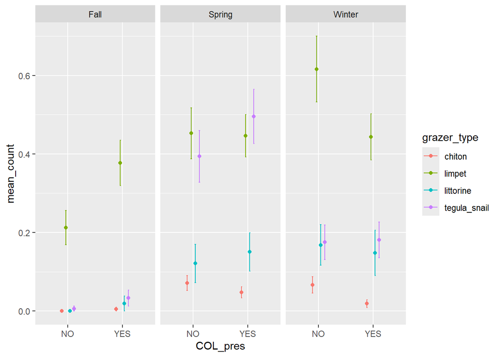

```r
summary_grazers <- grazers_types %>%
  mutate(log_count = log(count+1)) %>%
  group_by(grazer_type, Season, COL_pres) %>%
  summarize(mean_count = mean(log_count, na.rm = TRUE),
          se_count = sd(log_count, na.rm = TRUE)/sqrt(n()))

grazer_summary_plot <- summary_grazers %>%
  ggplot(aes(x = COL_pres,
             y = mean_count,
             color = grazer_type))+
  geom_point(position = position_dodge(width = 0.3))+ #this code helps spread apart the error bars
  geom_errorbar(aes(ymin=mean_count-se_count, ymax=mean_count+se_count),
               width = 0.1,
               position = position_dodge(width = 0.3))+ #this code helps spread apart the error bars
  facet_wrap(~Season)
grazer_summary_plot
```

# Linear Models for Grazer Type

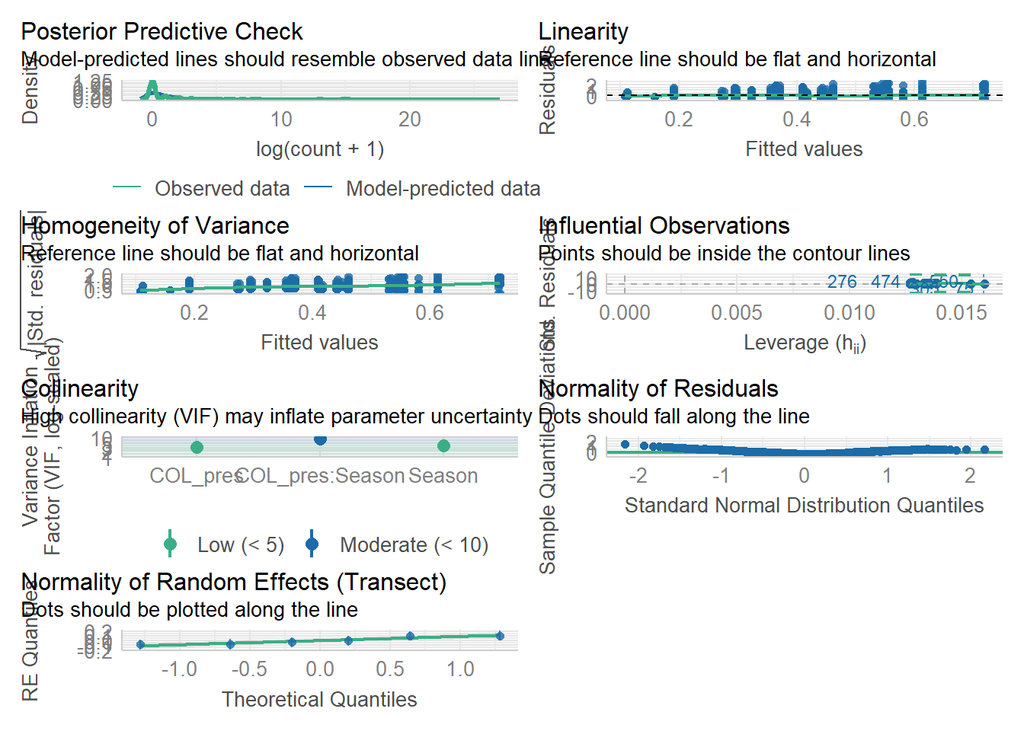

```r
limpet_lm <- lmer(log(count+1)~COL_pres*Season+(1|Transect),
                data = grazers_types %>%
                  filter(grazer_type == "limpet")) #change type

check_model(limpet_lm) #when I run the check function, I'm having a hard time seeing it
```

```r
anova(limpet_lm)
```

```
## Type III Analysis of Variance Table with Satterthwaite's method
##                 Sum Sq Mean Sq NumDF  DenDF F value    Pr(>F)
## COL_pres        0.0035  0.0035     1 707.96  0.0076 0.9303797
## Season          7.6319  3.8159     2 710.44  8.2354 0.0002912 ***
## COL_pres:Season 3.3008  1.6504     2 707.96  3.5618 0.0288969 *
## ---
## Signif. codes:  0 '***' 0.001 '**' 0.01 '*' 0.05 '.' 0.1 ' ' 1
```

# Trophic Type Graph

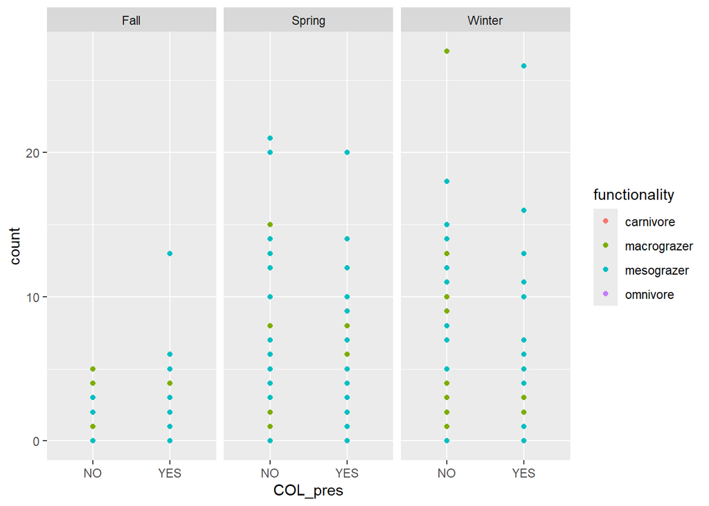

```r
trophic_type_mobiles <- long_mobiles %>%
  ggplot(aes(x = COL_pres,
             y= count,
             color = functionality)) +
  geom_point()+
  theme()+
  facet_wrap(~Season)
trophic_type_mobiles
```

# By species graph

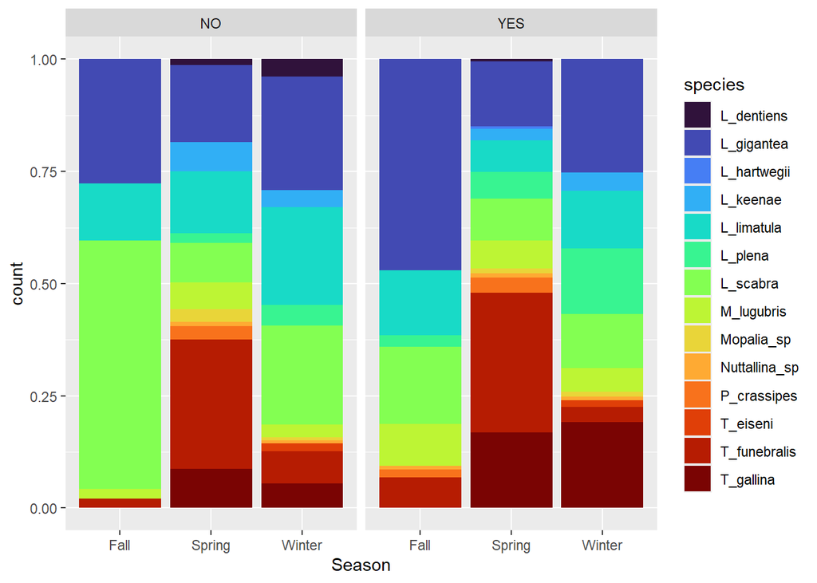

```r
by_species_mobiles <- long_mobiles %>%
  ggplot(aes(x = Season,
             y = count,
             fill = species)) +
  geom_bar(position="fill", stat="identity")+
  scale_fill_viridis_d(option = "H")+ #i like this graph but look for better fill colors
  theme()+
  facet_wrap(~COL_pres)
by_species_mobiles
```

```r
#axis.text.x = element_text(angle = 90, vjust = 0.5, hjust = 1
```

# Small owl Limpets Present in Presence of Large Owl Limpet

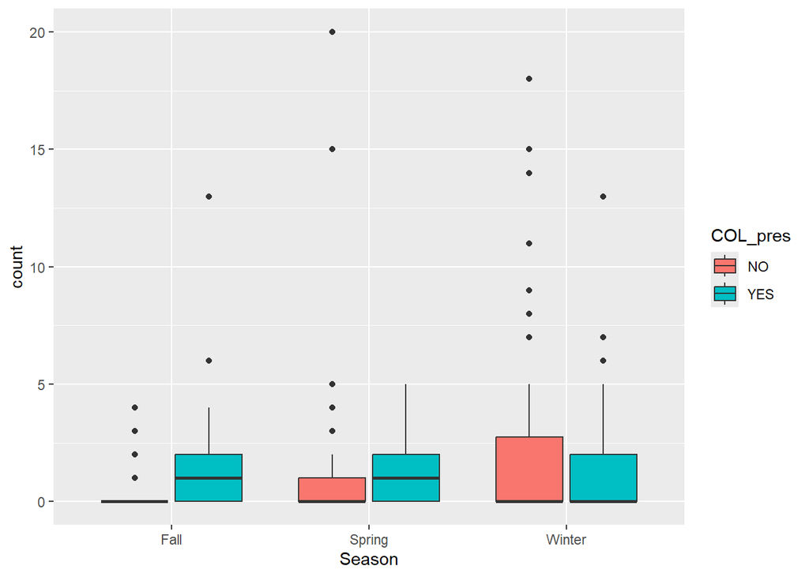

```r
smalls_with_big <- long_mobiles %>%
  filter(species=="L_gigantea")

small_with_big_boxplot <- ggplot(smalls_with_big,
                                 aes(x=Season,
                                     y= count,
                                     fill = COL_pres))+
  geom_boxplot()
small_with_big_boxplot
```

# Temperature Data

I need to work out this chunck

```r
#temperature_by_season <-master_temperature_data %>%
  #group_by(Season)%>%
  #separate(Date_Time, into = c("date_col", "time_col"), sep = " ", remove = FALSE) %>%
  #summarise(mean_temp = mean(Temperature.C, na.rm = TRUE),
           # max_temp = max(Temperature.C, na.rm = TRUE),
            #min_temp = min(Temperature.C, na.rm = TRUE))

#ggplot(temperature_by_season, aes(x =Season, y = ))+
 # geom_line()+
 # geom_point(aes(color = Season))
```